[figure not shown]

# Data Science and Business Analytics

# Project 5 : SUPERVISED LEARNING

# ENSEMBLE TECHNIQUE : EASY VISA

# Problem Statement

## **Context:**

Business communities in the United States are facing high demand for human resources, but one of the constant challenges is identifying and attracting the right talent, which is perhaps the most important element in remaining competitive. Companies in the United States look for hard-working, talented, and qualified individuals both locally as well as abroad.

The Immigration and Nationality Act (INA) of the US permits foreign workers to come to the United States to work on either a temporary or permanent basis. The act also protects US workers against adverse impacts on their wages or working conditions by ensuring US employers' compliance with statutory requirements when they hire foreign workers to fill workforce shortages. The immigration programs are administered by the Office of Foreign Labor Certification (OFLC).

OFLC processes job certification applications for employers seeking to bring foreign workers into the United States and grants certifications in those cases where employers can demonstrate that there are not sufficient US workers available to perform the work at wages that meet or exceed the wage paid for the occupation in the area of intended employment.

### **Objective:**

In FY 2016, the OFLC processed 775,979 employer applications for 1,699,957 positions for temporary and permanent labor certifications. This was a nine percent increase in the overall number of processed applications from the previous year. The process of reviewing every case is becoming a tedious task as the number of applicants is increasing every year.

The increasing number of applicants every year calls for a Machine Learning based solution that can help in shortlisting the candidates having higher chances of VISA approval. OFLC has hired the firm EasyVisa for data-driven solutions. You as a data scientist at EasyVisa have to analyze the data provided and, with the help of a classification model:

- Facilitate the process of visa approvals.
- Recommend a suitable profile for the applicants for whom the visa should be certified or denied based on the drivers that significantly influence the case status.

### **Data Description**

The data contains the different attributes of employee and the employer. The detailed data dictionary is given below.

- case_id: ID of each visa application
- continent: Information of continent the employee
- education_of_employee: Information of education of the employee
- has_job_experience: Does the employee has any job experience? Y= Yes; N = No
- requires_job_training: Does the employee require any job training? Y = Yes; N = No
- no_of_employees: Number of employees in the employer's company
- yr_of_estab: Year in which the employer's company was established
- region_of_employment: Information of foreign worker's intended region of employment in the US.
- prevailing_wage: Average wage paid to similarly employed workers in a specific occupation in the area of intended employment. The purpose of the prevailing wage is to ensure that the foreign worker is not underpaid compared to other workers offering the same or similar service in the same area of employment.
- unit_of_wage: Unit of prevailing wage. Values include Hourly, Weekly, Monthly, and Yearly.
- full_time_position: Is the position of work full-time? Y = Full Time Position; N = Part Time Position
- case_status: Flag indicating if the Visa was certified or denied

## Step 1 : Importing necessary libraries

```python
import warnings

warnings.filterwarnings("ignore")
from statsmodels.tools.sm_exceptions import ConvergenceWarning

warnings.simplefilter("ignore", ConvergenceWarning)

# Libraries to help with reading and manipulating data
import numpy as np
import pandas as pd

# libaries to help with data visualization
import seaborn as sns
import matplotlib.pyplot as plt

from datetime import date
import math                   #used during subplot visualization

# set size and style of the seaborn plots
sns.set(rc = {'figure.figsize':(15,8)})
sns.set_style("darkgrid")

# setting the precision of floating numbers to 4 decimal points
pd.set_option("display.float_format", lambda x: "%.4f" % x)

# Removes the limit for the number of displayed columns
pd.set_option("display.max_columns", None)
# Sets the limit for the number of displayed rows
pd.set_option("display.max_rows", 100)

# SL Library to split data
from sklearn.model_selection import train_test_split

# Libraries to build decision tree classifier and tune different models
from sklearn import tree
from sklearn.model_selection import GridSearchCV
from sklearn.tree import DecisionTreeClassifier

# To get diferent metric scores
from sklearn import metrics
from sklearn.metrics import (
    f1_score,
    accuracy_score,
    recall_score,
    precision_score,
    roc_auc_score,
    roc_curve,
    precision_recall_curve,
    confusion_matrix,
    classification_report,
    make_scorer,
)

# Libraries for different ensemble classifiers
from xgboost import XGBClassifier
from sklearn.ensemble import (
    BaggingClassifier,
    RandomForestClassifier,
    GradientBoostingClassifier,
    AdaBoostClassifier,
    StackingClassifier,
)
```

## Step 2 : Loading the Data

```python
# for mounting the dataset from Google Drive

from google.colab import drive
drive.mount('/content/drive')

#Loading dataset
visa = pd.read_csv('/content/drive/MyDrive/Colab Notebooks/Projects/Project 5/EasyVisa.csv')
```

```python
# copying data to another variable to avoid any changes to original data
data = visa.copy()
```

## Step 3: Perform exploratory data analysis (EDA)

- Perform exploratory data analysis (EDA) to understand the data and identify any incorrect data, missing values or outliers, perform correlation
- Do all the necessary data checkings to pepare for Pre-Process Step 4

## Data Overview & Sanity Check

### View the first and last 5 rows of the dataset

```python
data.head()  ## top 5 rows of the data
```

|  | case_id | continent | education_of_employee | has_job_experience | requires_job_training | no_of_employees | yr_of_estab | region_of_employment | prevailing_wage | unit_of_wage | full_time_position | case_status |
| --- | --- | --- | --- | --- | --- | --- | --- | --- | --- | --- | --- | --- |
| 0 | EZYV01 | Asia | High School | N | N | 14513 | 2007 | West | 592.2029 | Hour | Y | Denied |
| 1 | EZYV02 | Asia | Master's | Y | N | 2412 | 2002 | Northeast | 83425.6500 | Year | Y | Certified |
| 2 | EZYV03 | Asia | Bachelor's | N | Y | 44444 | 2008 | West | 122996.8600 | Year | Y | Denied |
| 3 | EZYV04 | Asia | Bachelor's | N | N | 98 | 1897 | West | 83434.0300 | Year | Y | Denied |
| 4 | EZYV05 | Africa | Master's | Y | N | 1082 | 2005 | South | 149907.3900 | Year | Y | Certified |

```python
data.tail()  ## last 5 rows of the data
```

|  | case_id | continent | education_of_employee | has_job_experience | requires_job_training | no_of_employees | yr_of_estab | region_of_employment | prevailing_wage | unit_of_wage | full_time_position | case_status |
| --- | --- | --- | --- | --- | --- | --- | --- | --- | --- | --- | --- | --- |
| 25475 | EZYV25476 | Asia | Bachelor's | Y | Y | 2601 | 2008 | South | 77092.5700 | Year | Y | Certified |
| 25476 | EZYV25477 | Asia | High School | Y | N | 3274 | 2006 | Northeast | 279174.7900 | Year | Y | Certified |
| 25477 | EZYV25478 | Asia | Master's | Y | N | 1121 | 1910 | South | 146298.8500 | Year | N | Certified |
| 25478 | EZYV25479 | Asia | Master's | Y | Y | 1918 | 1887 | West | 86154.7700 | Year | Y | Certified |
| 25479 | EZYV25480 | Asia | Bachelor's | Y | N | 3195 | 1960 | Midwest | 70876.9100 | Year | Y | Certified |

### Verify the number of rows and columns of the dataset.

```python
data.shape  #check shape of the datasets
```

```
(25480, 12)
```

### Verify if there are any duplicates in the dataset.

```python
data.duplicated().sum()
```

```
0
```

```python
data[data.duplicated()].count()
```

```
case_id                  0
continent                0
education_of_employee    0
has_job_experience       0
requires_job_training    0
no_of_employees          0
yr_of_estab              0
region_of_employment     0
prevailing_wage          0
unit_of_wage             0
full_time_position       0
case_status              0
dtype: int64
```

### Checking for unique values of each column

```python
print("Unique values in dataset: \n\n",data.nunique())
```

```
Unique values in dataset:

 case_id                  25480
continent                    6
education_of_employee        4
has_job_experience           2
requires_job_training        2
no_of_employees           7105
yr_of_estab                199
region_of_employment         5
prevailing_wage          25454
unit_of_wage                 4
full_time_position           2
case_status                  2
dtype: int64
```

### Check the data types of the columns for the dataset

```python
data.dtypes
```

```
case_id                   object
continent                 object
education_of_employee     object
has_job_experience        object
requires_job_training     object
no_of_employees            int64
yr_of_estab                int64
region_of_employment      object
prevailing_wage          float64
unit_of_wage              object
full_time_position        object
case_status               object
dtype: object
```

```python
data.info()
```

```
<class 'pandas.core.frame.DataFrame'>
RangeIndex: 25480 entries, 0 to 25479
Data columns (total 12 columns):
 #   Column                 Non-Null Count  Dtype
---  ------                 --------------  -----
 0   case_id                25480 non-null  object
 1   continent              25480 non-null  object
 2   education_of_employee  25480 non-null  object
 3   has_job_experience     25480 non-null  object
 4   requires_job_training  25480 non-null  object
 5   no_of_employees        25480 non-null  int64
 6   yr_of_estab            25480 non-null  int64
 7   region_of_employment   25480 non-null  object
 8   prevailing_wage        25480 non-null  float64
 9   unit_of_wage           25480 non-null  object
 10  full_time_position     25480 non-null  object
 11  case_status            25480 non-null  object
dtypes: float64(1), int64(2), object(9)
memory usage: 2.3+ MB
```

### Check for Missing Values

```python
data.isnull().sum().sort_values(ascending=False)  # sort descending
```

```
case_id                  0
continent                0
education_of_employee    0
has_job_experience       0
requires_job_training    0
no_of_employees          0
yr_of_estab              0
region_of_employment     0
prevailing_wage          0
unit_of_wage             0
full_time_position       0
case_status              0
dtype: int64
```

**Data Overview Observations**

- Data set loaded properly. No issues.
- There are 25,480 records and 12 columns (fields)
- There are no duplicate records and missing values which makes it a good data set and also means we do not have to carry out any data impute
- There are 3 different datatypes in the dataset : float64(1), int64(2) and object(9).
- Dependent variable (test variable) is case_status which is a categorical column
- Independent categorical variables are : case_id, continent,education_of_employee, has_job_experience, requires_job_training, region_of_employment, unit_of_wage, full_time_position.
- Independent numerical variables are : no_of_employees, yr_of_estab and prevailing_wage
- We will drop unnecessary categorical column - case_id during pre-processing as we may want to use this for the EDA
- case_status which is our test result should be a binary representation, of either '1' or '0' (True / False).

### Dropping Unnecessary Columns

```python
data.drop(['case_id'],axis=1,inplace=True)
```

### Lets breakdown or verify the categorical data further

```python
data.describe(include = 'object')
```

|  | continent | education_of_employee | has_job_experience | requires_job_training | region_of_employment | unit_of_wage | full_time_position | case_status |
| --- | --- | --- | --- | --- | --- | --- | --- | --- |
| count | 25480 | 25480 | 25480 | 25480 | 25480 | 25480 | 25480 | 25480 |
| unique | 6 | 4 | 2 | 2 | 5 | 4 | 2 | 2 |
| top | Asia | Bachelor's | Y | N | Northeast | Year | Y | Certified |
| freq | 16861 | 10234 | 14802 | 22525 | 7195 | 22962 | 22773 | 17018 |

```python
# filtering object type columns
cat_columns = data.describe(include=["object"]).columns
cat_columns
```

```
Index(['continent', 'education_of_employee', 'has_job_experience',
       'requires_job_training', 'region_of_employment', 'unit_of_wage',
       'full_time_position', 'case_status'],
      dtype='object')
```

```python
for i in cat_columns:
    print(data[i].value_counts())
    print("*" * 40)
    print("\n")
    print(data[i].describe())
    print("*" * 40)
    print("\n")
```

```
Asia             16861
Europe            3732
North America     3292
South America      852
Africa             551
Oceania            192
Name: continent, dtype: int64


count     25480
unique        6
top        Asia
freq      16861
Name: continent, dtype: object


Bachelor's     10234
Master's        9634
High School     3420
Doctorate       2192
Name: education_of_employee, dtype: int64


count          25480
unique             4
top       Bachelor's
freq           10234
Name: education_of_employee, dtype: object


Y    14802
N    10678
Name: has_job_experience, dtype: int64


count     25480
unique        2
top           Y
freq      14802
Name: has_job_experience, dtype: object
```

[output cut: 50 more lines]

```
top           Y
freq      22773
Name: full_time_position, dtype: object


Certified    17018
Denied        8462
Name: case_status, dtype: int64


count         25480
unique            2
top       Certified
freq          17018
Name: case_status, dtype: object
```

**Observation of Categorical Statistical Summary**

### Check Statistical Summary

```python
data.describe().T
```

|  | count | mean | std | min | 25% | 50% | 75% | max |
| --- | --- | --- | --- | --- | --- | --- | --- | --- |
| no_of_employees | 25480.0000 | 5667.0432 | 22877.9288 | -26.0000 | 1022.0000 | 2109.0000 | 3504.0000 | 602069.0000 |
| yr_of_estab | 25480.0000 | 1979.4099 | 42.3669 | 1800.0000 | 1976.0000 | 1997.0000 | 2005.0000 | 2016.0000 |
| prevailing_wage | 25480.0000 | 74455.8146 | 52815.9423 | 2.1367 | 34015.4800 | 70308.2100 | 107735.5125 | 319210.2700 |

```python
data.describe(include ='all').T
```

|  | count | unique | top | freq | mean | std | min | 25% | 50% | 75% | max |
| --- | --- | --- | --- | --- | --- | --- | --- | --- | --- | --- | --- |
| continent | 25480 | 6 | Asia | 16861 | NaN | NaN | NaN | NaN | NaN | NaN | NaN |
| education_of_employee | 25480 | 4 | Bachelor's | 10234 | NaN | NaN | NaN | NaN | NaN | NaN | NaN |
| has_job_experience | 25480 | 2 | Y | 14802 | NaN | NaN | NaN | NaN | NaN | NaN | NaN |
| requires_job_training | 25480 | 2 | N | 22525 | NaN | NaN | NaN | NaN | NaN | NaN | NaN |
| no_of_employees | 25480.0000 | NaN | NaN | NaN | 5667.0432 | 22877.9288 | -26.0000 | 1022.0000 | 2109.0000 | 3504.0000 | 602069.0000 |
| yr_of_estab | 25480.0000 | NaN | NaN | NaN | 1979.4099 | 42.3669 | 1800.0000 | 1976.0000 | 1997.0000 | 2005.0000 | 2016.0000 |
| region_of_employment | 25480 | 5 | Northeast | 7195 | NaN | NaN | NaN | NaN | NaN | NaN | NaN |
| prevailing_wage | 25480.0000 | NaN | NaN | NaN | 74455.8146 | 52815.9423 | 2.1367 | 34015.4800 | 70308.2100 | 107735.5125 | 319210.2700 |
| unit_of_wage | 25480 | 4 | Year | 22962 | NaN | NaN | NaN | NaN | NaN | NaN | NaN |
| full_time_position | 25480 | 2 | Y | 22773 | NaN | NaN | NaN | NaN | NaN | NaN | NaN |
| case_status | 25480 | 2 | Certified | 17018 | NaN | NaN | NaN | NaN | NaN | NaN | NaN |

Observation to Note

- On average, the companies in the dataset have around 5,667 employees. However, the standard deviation of 22,877 indicates that there is a large variation in the number of employees across the companies, which is indicative of a highly dispersed or skewed distribution with several outliers.
- Since the mean of 5667 is larger than the median of 2109 it suggests that the distribution of the "no_of_employees" variable is right-skewed. This means that the tail of the distribution extends towards larger values, and there are relatively few companies with a large number of employees as compared to the number of companies with a small number of employees.
- The data also shows minimum No of Employees with a negative value. This is not possible in a practical sense. It may indicate data entry errors or other anomalies in the dataset. It would be necessary to take appropriate measures to correct or remove them before further analysis.
- The data shows that there are companies in the dataset established between 1800 and 2016, with a mean of 1979. This indicates that the majority of the companies in the dataset were established in the 20th century.
- There seems to be companies in the dataset with year of establishement 1800 (over 200 yars old). Again this value may be invalid and could be an outlier.
- The prevailing wage data ranges from USD2.13 to USD319,210. The mean of USD74,455 indicates that the prevailing wage is relatively high, but the large standard deviation of 52,815 suggest that there is a wide range of wages across the companies in the dataset.
- The mean prevailing wage for occupation is USD 74,455 while the median (~50th percentile of wages) is USD 70,308. This indicates, slight right skewness in the data set as well.
- The minimum prevailing wage is 2.1367 which is a very low wage and something that needs to be looked at.

### Fixing Negative values Employees columns

```python
##  returns the number of rows in the dataset where the "no_of_employees" variable is less than 0.
num_neg_value= data.loc[data["no_of_employees"] < 0].shape[0]
num_neg_value

per_neg_value = (num_neg_value / data.shape[0]) * 100
print('Number of records with negative values are',num_neg_value, 'and''\nPercentage of negative values in dataset for employee column is:',per_neg_value)
```

```
Number of records with negative values are 33 and
Percentage of negative values in dataset for employee column is: 0.12951334379905807
```

**Observations**

- Total of 33 observations having negative values in the employee column dataset
- Although the percentage (0.13%) is very small, we will rectify it rather than remove the rows. Also since there are values present (not missing or incomplete), we will convert the -ve values to +ve values

```python
# taking the absolute values for number of employees to convert -ve to +ve
data["no_of_employees"] = abs(data["no_of_employees"])
```

```python
## run a check again to see if there are any negative values in the employee column
num_neg_value = data.loc[data["no_of_employees"] < 0].shape [0]

print('Number of records in no_of_employees column with negative values now are :',num_neg_value)
```

```
Number of records in no_of_employees column with negative values now are : 0
```

# **Exploratory Data Analysis (EDA)**

### PREDEFINED FUNCTIONS

- lets place some predefined functions here to be used during EDA

```python
def histogram_boxplot(data, feature, figsize=(15, 10), kde=True, bins=None):
    """
    Boxplot and histogram combined

    data: dataframe
    feature: dataframe column
    figsize: size of figure (default (15,10))
    kde: whether to show the density curve (default False)
    bins: number of bins for histogram (default None)
    """
    f2, (ax_box2, ax_hist2) = plt.subplots(
        nrows=2,  # Number of rows of the subplot grid= 2
        sharex=True,  # x-axis will be shared among all subplots
        gridspec_kw={"height_ratios": (0.25, 0.75)},
        figsize=figsize,
    )  # creating the 2 subplots
    sns.boxplot(
        data=data, x=feature, ax=ax_box2, showmeans=True, color="violet"
    )  # boxplot will be created and a triangle will indicate the mean value of the column
    sns.histplot(
        data=data, x=feature, kde=kde, ax=ax_hist2, bins=bins
    ) if bins else sns.histplot(
        data=data, x=feature, kde=kde, ax=ax_hist2
    )  # For histogram
    ax_hist2.axvline(
        data[feature].mean(), color="green", linestyle="--"
    )  # Add mean to the histogram
    ax_hist2.axvline(
        data[feature].median(), color="black", linestyle="-"
    )  # Add median to the histogram
```

```python
# function to create labeled barplots

def labeled_barplot(data, feature, perc=True, n=None):
    """
    Barplot with percentage at the top

    data: dataframe
    feature: dataframe column
    perc: whether to display percentages instead of count (default is False)
    n: displays the top n category levels (default is None, i.e., display all levels)
    """

    total = len(data[feature])  # length of the column
    count = data[feature].nunique()
    if n is None:
        plt.figure(figsize=(count + 2, 5))
    else:
        plt.figure(figsize=(n + 2, 5))

    plt.xticks(rotation=90, fontsize=10)
    ax = sns.countplot(
        data=data,
        x=feature,
        palette="Paired",
        order=data[feature].value_counts().index[:n],
    )

    for p in ax.patches:
        if perc == True:
            label = "{:.1f}%".format(
                100 * p.get_height() / total
            )  # percentage of each class of the category
        else:
            label = p.get_height()  # count of each level of the category

        x = p.get_x() + p.get_width() / 2  # width of the plot
        y = p.get_height()  # height of the plot

        ax.annotate(
            label,
            (x, y),
            ha="center",
            va="center",
            size=10,
            xytext=(0, 3),
            textcoords="offset points",
        )  # annotate the percentage

    plt.show()  # show the plot
```

```python
def stacked_barplot(data, predictor, target):
    """
    Print the category counts and plot a stacked bar chart

    data: dataframe
    predictor: independent variable
    target: target variable
    """
    count = data[predictor].nunique()
    sorter = data[target].value_counts().index[-1]
    tab1 = pd.crosstab(data[predictor], data[target], margins=True).sort_values(
        by=sorter, ascending=False
    )
    print(tab1)
    print("-" * 120)
    tab = pd.crosstab(data[predictor], data[target], normalize="index").sort_values(
        by=sorter, ascending=False
    )
    tab.plot(kind="bar", stacked=True, figsize=(count + 5, 5))
    plt.legend(
        loc="lower left", frameon=False,
    )
    plt.legend(loc="upper left", bbox_to_anchor=(1, 1))
    plt.show()
```

```python
### function to plot distributions wrt target

def distribution_plot_wrt_target(data, predictor, target):

    fig, axs = plt.subplots(2, 2, figsize=(12, 10))

    target_uniq = data[target].unique()

    axs[0, 0].set_title("Distribution of target for target=" + str(target_uniq[0]))
    sns.histplot(
        data=data[data[target] == target_uniq[0]],
        x=predictor,
        kde=True,
        ax=axs[0, 0],
        color="teal",
        stat="density",
    )

    axs[0, 1].set_title("Distribution of target for target=" + str(target_uniq[1]))
    sns.histplot(
        data=data[data[target] == target_uniq[1]],
        x=predictor,
        kde=True,
        ax=axs[0, 1],
        color="orange",
        stat="density",
    )

    axs[1, 0].set_title("Boxplot w.r.t target")
    sns.boxplot(data=data, x=target, y=predictor, ax=axs[1, 0], palette="gist_rainbow")

    axs[1, 1].set_title("Boxplot (without outliers) w.r.t target")
    sns.boxplot(
        data=data,
        x=target,
        y=predictor,
        ax=axs[1, 1],
        showfliers=False,
        palette="gist_rainbow",
    )

    plt.tight_layout()
    plt.show()
```

### **A. EDA - UNIVARIATE ANALYSIS**

*Lets take a look at all the Numerical Variables first*

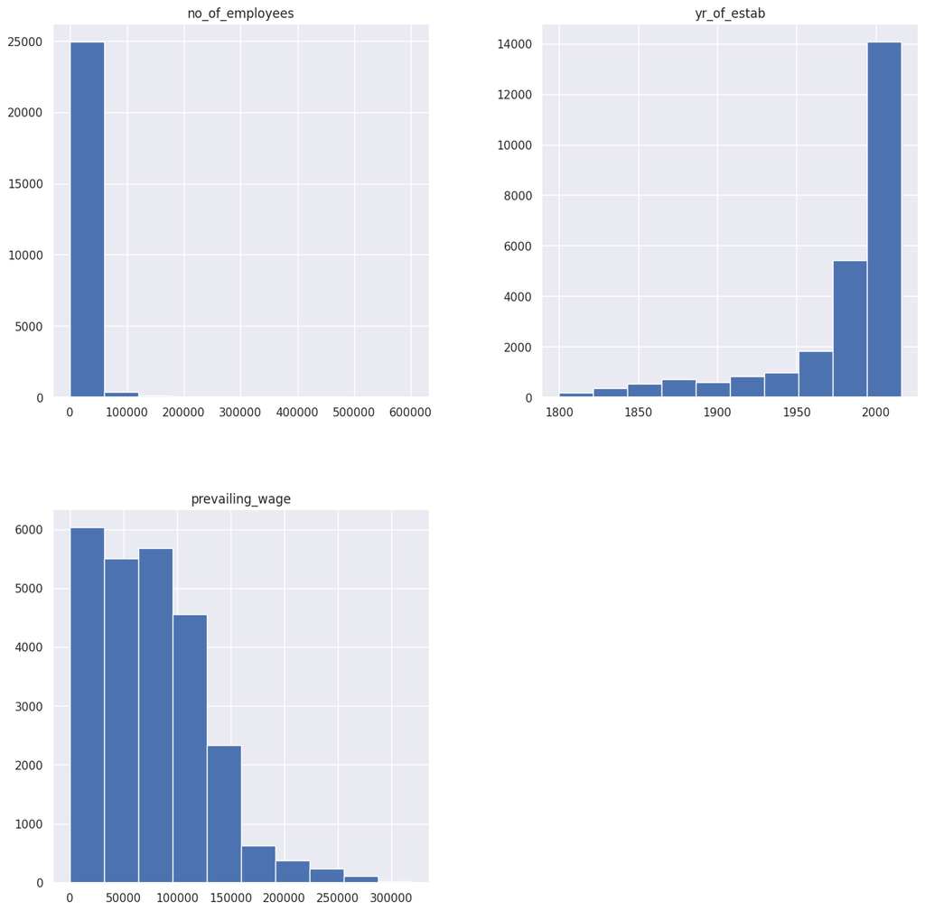

```python
data.hist(figsize=(15, 15))
plt.show()
```

### A2. Observations on number of employees

```python
# after converting the negative values in the employee column, to run the statistics again
data['no_of_employees'].describe()
```

```
count    25480.0000
mean      5667.0892
std      22877.9175
min         11.0000
25%       1022.0000
50%       2109.0000
75%       3504.0000
max     602069.0000
Name: no_of_employees, dtype: float64
```

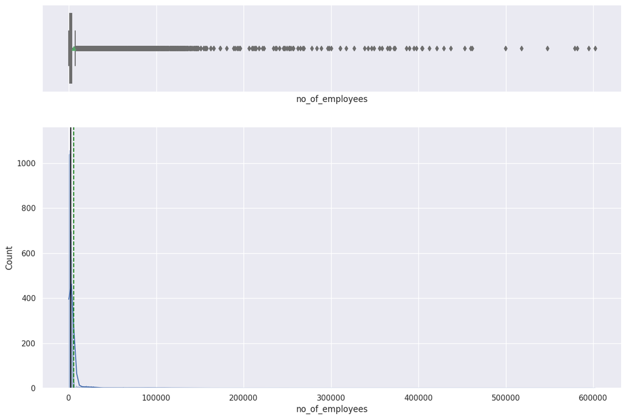

```python
histogram_boxplot(data, "no_of_employees")
```

**Observations**

- the visual plot for no_of_employees shows a right-skewed distribution with lots of outliers on the high end of the distribution
- Avg. number of employees is 5667, Min no of employees in a given organization = 11, the largest value is 602,069 employees
- 25% of the companies have fewer than 1022 employees, while 75% of the companies have fewer than 3504 employees.

### A3. Observations on Year of Establishment

```python
data['yr_of_estab'].describe()
```

```
count   25480.0000
mean     1979.4099
std        42.3669
min      1800.0000
25%      1976.0000
50%      1997.0000
75%      2005.0000
max      2016.0000
Name: yr_of_estab, dtype: float64
```

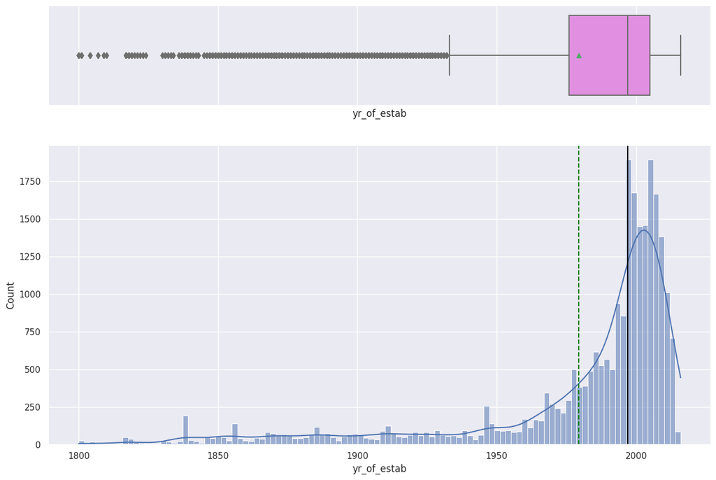

```python
histogram_boxplot(data, 'yr_of_estab')
```

**Observation**

### A4. Observations on prevailing wage

```python
data['prevailing_wage'].describe()
```

```
count    25480.0000
mean     74455.8146
std      52815.9423
min          2.1367
25%      34015.4800
50%      70308.2100
75%     107735.5125
max     319210.2700
Name: prevailing_wage, dtype: float64
```

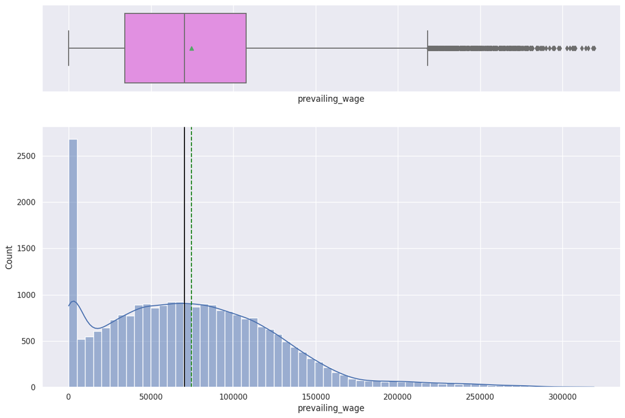

```python
histogram_boxplot(data, 'prevailing_wage')
```

```python
skewness = pd.Series(data["prevailing_wage"]).skew()
print("Skewness of prevailing_wage column:", skewness)
```

```
Skewness of prevailing_wage column: 0.7557760603032042
```

Observations

*Lets take a look at all the Categorical Variables next*

### A5. Observations on target variable : case_status

```python
data['case_status'].value_counts()
```

```
Certified    17018
Denied        8462
Name: case_status, dtype: int64
```

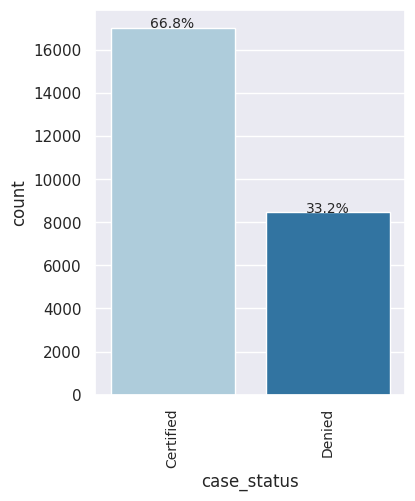

```python
labeled_barplot(data, "case_status", perc=True)
```

**Observations**

- 67% (17,018 cases) of the visa aplications were Certified and 33% (8,462 cases) where "Denied".

### A6. Observations on continent

```python
data['continent'].value_counts()
```

```
Asia             16861
Europe            3732
North America     3292
South America      852
Africa             551
Oceania            192
Name: continent, dtype: int64
```

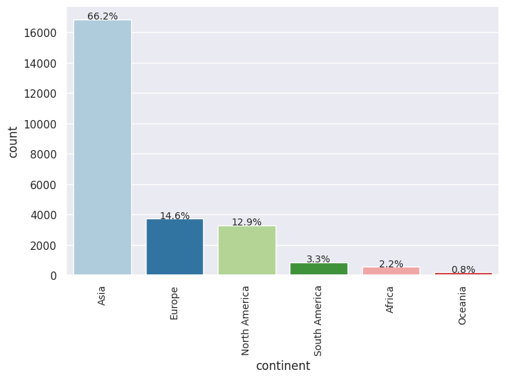

```python
labeled_barplot(data, "continent")
```

**Observations**

- The majority of visa applicants are from the Asia continent (66.2% or 16,861 applications)
- North America and Europe have close application range
- The least visa applicants come from the Oceania continents (0.8%)

### A7. Observations on education of employee

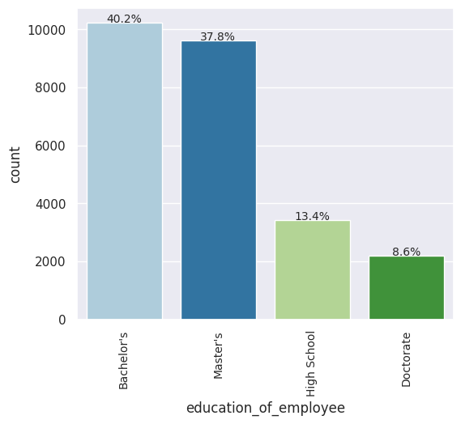

```python
labeled_barplot(data, "education_of_employee")
```

**Observations**

- The majority (40.2%) of visa applicants hold a bachelor's degree, followed by Master's
- Least application is of Doctorate degree (8.6%)

### A8. Observations on job experience

```python
data['has_job_experience'].value_counts()
```

```
Y    14802
N    10678
Name: has_job_experience, dtype: int64
```

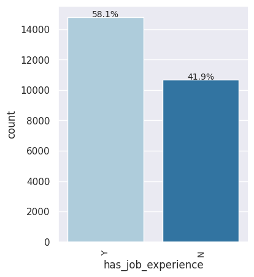

```python
labeled_barplot(data, 'has_job_experience')
```

**Observations**

- 58% of visa applicants have job experience
- And 42% have no job experience

### A9. Observations on job training

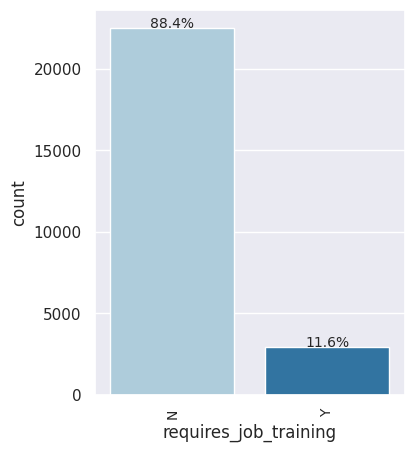

```python
labeled_barplot(data,'requires_job_training')
```

**Observations**

- 88% of visa applicants do not require job training
- Wherelse, 12% require job training

### A10. Observations on region of employment

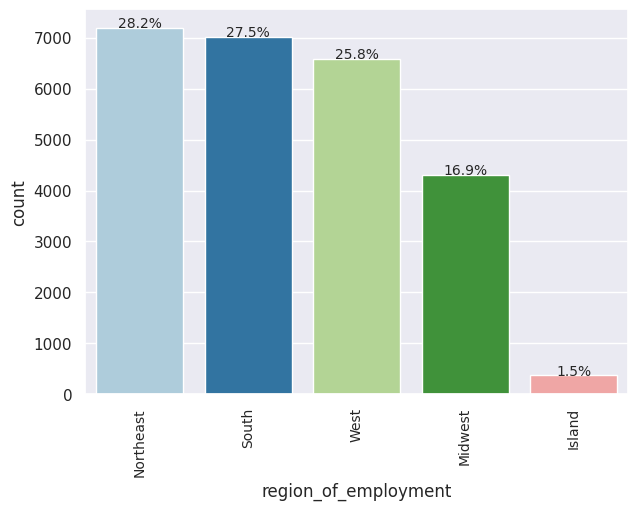

```python
labeled_barplot(data,'region_of_employment')
```

**Observations**

- The majority of intended region of employment in the US applies most to the Northeast region which makes up 28% of visa applicants, followed by the South (27.5%) and West region(25.8%)
- The least intended region for employment is the Island (1.5%)

### A11. Observations on unit of wage

```python
data['unit_of_wage'].value_counts()
```

```
Year     22962
Hour      2157
Week       272
Month       89
Name: unit_of_wage, dtype: int64
```

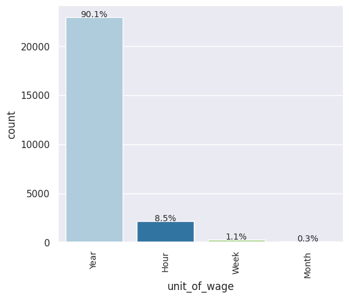

```python
labeled_barplot(data, 'unit_of_wage')
```

**Observations**

- 90% of all visa applicants show a yearly unit wage
- Very negligible Weekly and Monthly unit of wage.

### A12. Lets looks at the Prevaling Wages by the Unit of Wage next

```python
#summary of the prevailing_wage values for rows where the wage unit is only "Year".
data.loc[data['unit_of_wage']=='Year']['prevailing_wage'].describe()
```

```
count    22962.0000
mean     81228.0771
std      49951.4732
min        100.0000
25%      43715.9550
50%      76174.5000
75%     111341.9600
max     319210.2700
Name: prevailing_wage, dtype: float64
```

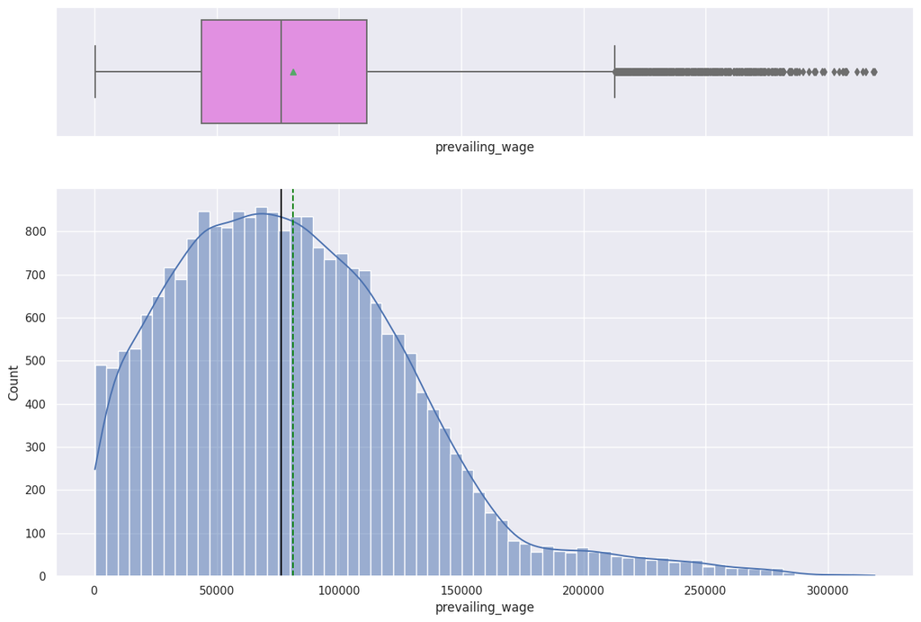

```python
'''
filters the input data by selecting only the rows where the unit_of_wage column is "Year".
using a histogram and box plot of the prevailing_wage column
which only includes rows where the unit_of_wage column is equal to "Year".
'''
histogram_boxplot(data[(data['unit_of_wage']=='Year')], 'prevailing_wage')
```

**Observation**

```python
#summary of the prevailing_wage values for rows where the wage unit is only "Month".
data.loc[data['unit_of_wage']=='Month']['prevailing_wage'].describe()
```

```
count       89.0000
mean     87592.8640
std      59525.1249
min       1599.2800
25%      44986.2400
50%      81826.0100
75%     121629.6000
max     264362.9500
Name: prevailing_wage, dtype: float64
```

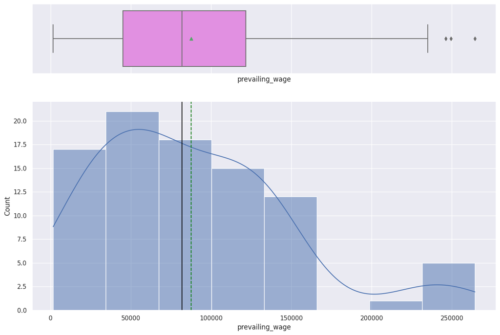

```python
histogram_boxplot(data[(data['unit_of_wage']=='Month')], 'prevailing_wage')
```

**Observation**

*Some potential areas for further investigation could be included in the dataset:*

- Occupational breakdown: Examining the distribution of prevailing wages by occupation
- Geographic breakdown: Analyzing the distribution of prevailing wages by location and not just be region alone
- Industry breakdown: Examining the distribution of prevailing wages by industry

**Note***

- Comparing the monthly and yearly prevailing wages, it seems that mean prevailing wages in the monthly dataset for H1B visa applicants tend to be higher than the yearly average.

```python
#summary of the prevailing_wage values for rows where the wage unit is only "Week".
data.loc[data['unit_of_wage']=='Week']['prevailing_wage'].describe()
```

```
count      272.0000
mean     85606.8205
std      44802.7048
min       2183.2300
25%      51408.2775
50%      85075.8200
75%     111331.9100
max     280175.9500
Name: prevailing_wage, dtype: float64
```

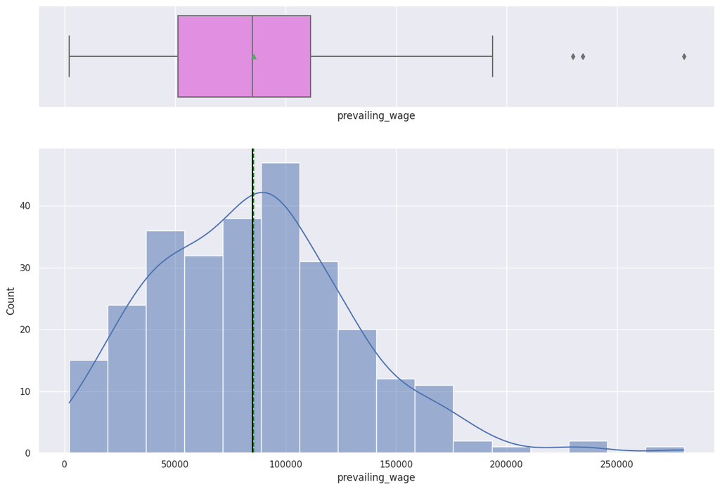

```python
histogram_boxplot(data[(data['unit_of_wage']=='Week')], 'prevailing_wage')
```

**Observations**

- there are 272 observations available where the wage unit is "Week".
- The mean prevailing wage is USD 85,606.82, with a standard deviation of USD 44,802.70.
- The minimum prevailing wage is USD 2,183.23, and the maximum prevailing wage is USD 280,175.95 per week. This would explain the outliers present in the visual plot.

```python
#summary of the prevailing_wage values for rows where the wage unit is only "Hour".
data.loc[data['unit_of_wage']=='Hour']['prevailing_wage'].describe()
```

```
count   2157.0000
mean     414.5705
std      275.0150
min        2.1367
25%      152.7003
50%      372.6523
75%      637.3111
max      999.9195
Name: prevailing_wage, dtype: float64
```

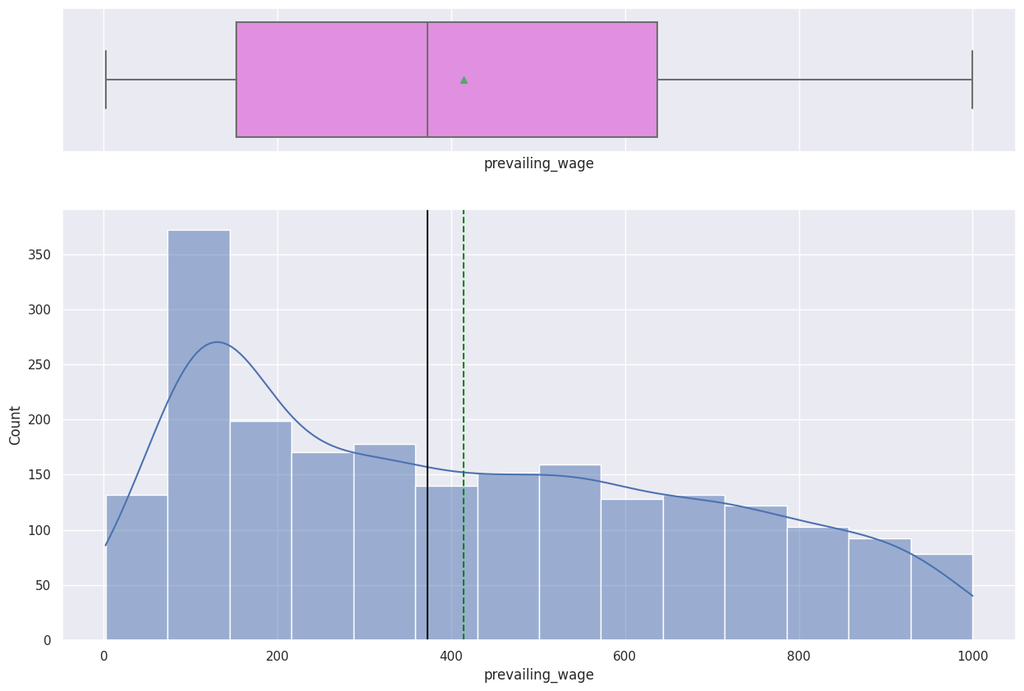

```python
histogram_boxplot(data[(data['unit_of_wage']=='Hour')], 'prevailing_wage')
```

**Observations**

The summary of the prevailing wage values for rows where the wage unit is only "Hour" indicates that:

- The dataset contains 2,157 visa applications with hourly wages.
- The mean hourly wage for these applications is USD 414.57.
- The standard deviation of the hourly wages is USD 275.01. The standard deviation is relatively high, indicating that the wages are widely spread out and there may be some significant outliers.
- The minimum hourly wage is USD 2.14 which seems unusually low, and it is possible that this value is an error or an outlier.
- The maximum hourly wage is USD 999.92, which is also not sensible or an outlier.
- The 25th percentile of hourly wages is USD 152.70, the 50th percentile is USD 372.65, and the 75th percentile is USD 637.31.

### **A13. Observation of employment position type**

```python
data['full_time_position'].value_counts()
```

```
Y    22773
N     2707
Name: full_time_position, dtype: int64
```

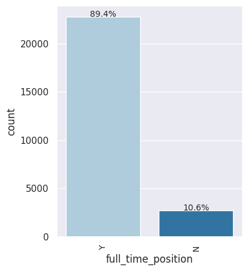

```python
labeled_barplot(data,'full_time_position')
```

**Observations**

- There are 22,773 (89.4%) applications that are of full-time positions

### **B. EDA - Bivariate Analysis**

Lesson Learned

- Normally i would do Corr Heatmap as the first step in Bivariate Analysis.
- However in this project, will carry out Bivariate Analysis first before Correlation heatmap as conversion of category var to numerical values caused bivariate analysis visuals to be challenging to analyse

#### **B1. Those with higher education may want to travel abroad for a well-paid job. Let's find out if education has any impact on visa certification**

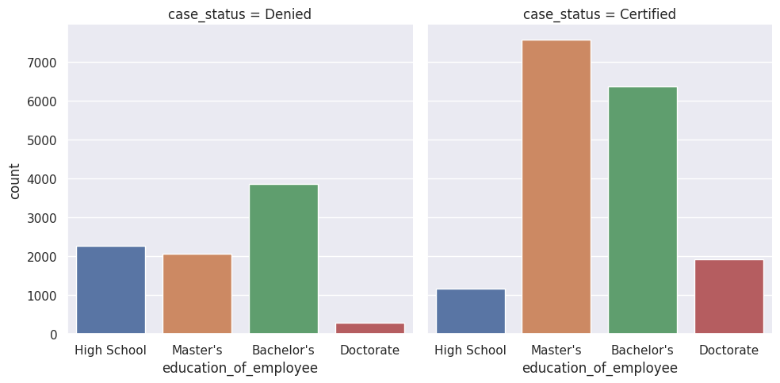

```python
sns.catplot(data = data, x = 'education_of_employee', col = 'case_status', kind = 'count')
plt.show()
```

```python
# create a crosstab table with percentage values
table = pd.crosstab(data['education_of_employee'], data['case_status'], normalize='index')
table['All'] = table.sum(axis=1)

# display the table with percentage values using the to_string() method
# formatters parameter maps column names to formatting functions
print(table.to_string(formatters={'Certified': '{:.2%}'.format, 'Denied': '{:.2%}'.format, 'All': '{:.2%}'.format}))
```

```
case_status           Certified Denied     All
education_of_employee
Bachelor's               62.21% 37.79% 100.00%
Doctorate                87.23% 12.77% 100.00%
High School              34.04% 65.96% 100.00%
Master's                 78.63% 21.37% 100.00%
```

```
case_status            Certified  Denied    All
education_of_employee
All                        17018    8462  25480
Bachelor's                  6367    3867  10234
High School                 1164    2256   3420
Master's                    7575    2059   9634
Doctorate                   1912     280   2192
------------------------------------------------------------------------------------------------------------------------
```

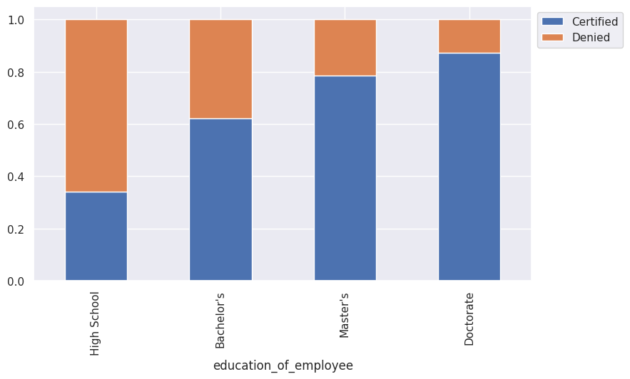

```python
stacked_barplot(data, "education_of_employee", "case_status")
```

*Visualization shows that education has some association with higher visa certification rates.*

#### **B2. Different regions have different requirements of talent having diverse educational backgrounds. Let's analyze it further**

```python
table = pd.crosstab(data['education_of_employee'], data['region_of_employment'])
print(table)
```

```
region_of_employment   Island  Midwest  Northeast  South  West
education_of_employee
Bachelor's                129     1315       2874   2991  2925
Doctorate                  25      256        656    541   714
High School                60      736        905    934   785
Master's                  161     2000       2760   2551  2162
```

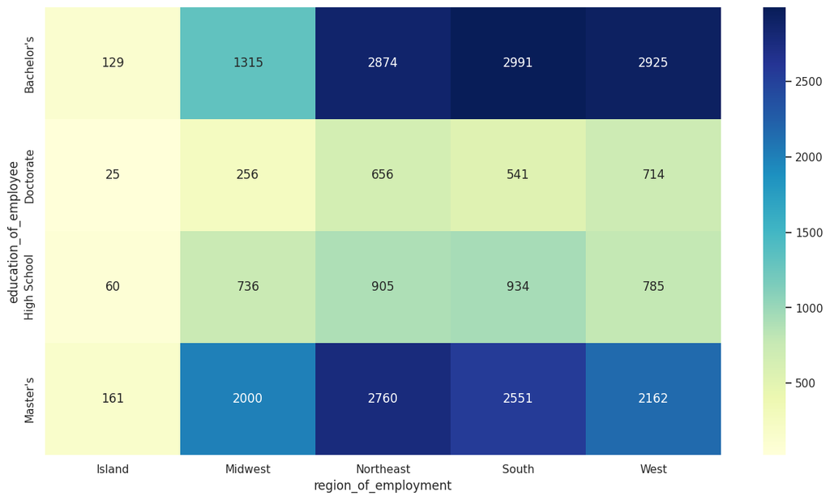

```python
#to plot heatmap for the crosstab
sns.heatmap(table, annot=True, fmt="d", cmap="YlGnBu")
plt.show()
```

*These results suggest that different regions have different requirements when it comes to the educational background of visa applicants.*

#### **B3. Let's have a look at the percentage of visa certifications across each region**

```python
# create a crosstab table with percentage values
table = pd.crosstab(data['region_of_employment'], data['case_status'], normalize='index')
table['All'] = table.sum(axis=1)

# display the table with percentage values using the to_string() method
# formatters parameter maps column names to formatting functions
print(table.to_string(formatters={'Certified': '{:.2%}'.format, 'Denied': '{:.2%}'.format, 'All': '{:.2%}'.format}))
```

```
case_status          Certified Denied     All
region_of_employment
Island                  60.27% 39.73% 100.00%
Midwest                 75.53% 24.47% 100.00%
Northeast               62.90% 37.10% 100.00%
South                   70.02% 29.98% 100.00%
West                    62.25% 37.75% 100.00%
```

```
case_status           Certified  Denied    All
region_of_employment
All                       17018    8462  25480
Northeast                  4526    2669   7195
West                       4100    2486   6586
South                      4913    2104   7017
Midwest                    3253    1054   4307
Island                      226     149    375
------------------------------------------------------------------------------------------------------------------------
```

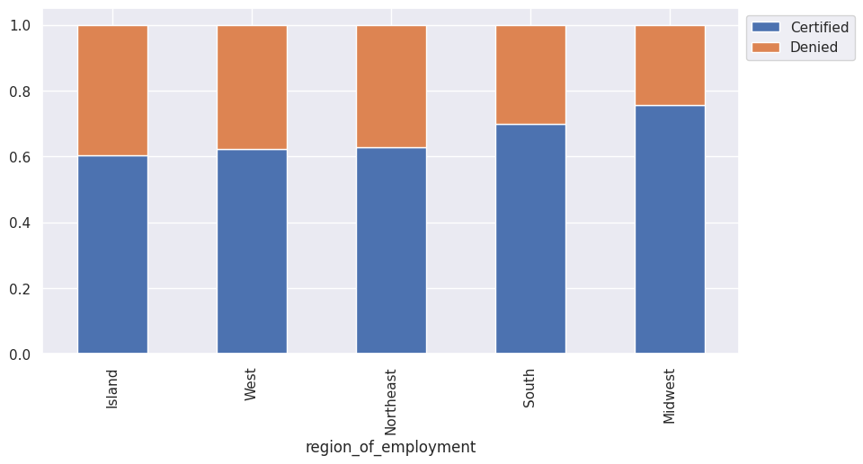

```python
stacked_barplot(data, "region_of_employment", "case_status")
```

#### **B4. Lets' similarly check for the continents and find out how the visa status vary across different continents**.

```
case_status    Certified  Denied    All
continent
All                17018    8462  25480
Asia               11012    5849  16861
North America       2037    1255   3292
Europe              2957     775   3732
South America        493     359    852
Africa               397     154    551
Oceania              122      70    192
------------------------------------------------------------------------------------------------------------------------
```

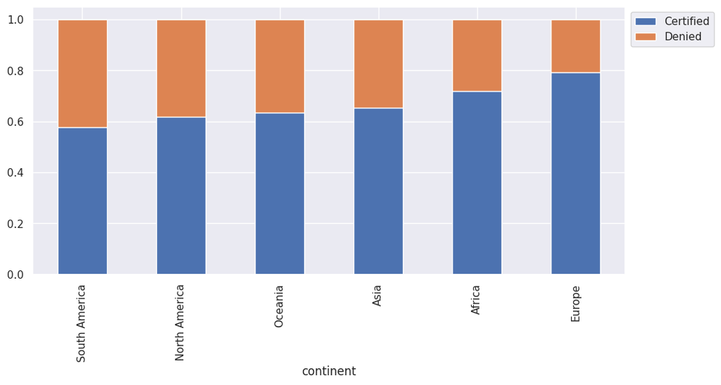

```python
stacked_barplot(data, "continent", "case_status")
```

```python
# create a crosstab table with percentage values
table = pd.crosstab(data['continent'], data['case_status'], normalize='index')
table['All'] = table.sum(axis=1)

# display the table with percentage values using the to_string() method
# formatters parameter maps column names to formatting functions
print(table.to_string(formatters={'Certified': '{:.2%}'.format, 'Denied': '{:.2%}'.format, 'All': '{:.2%}'.format}))
```

```
case_status   Certified Denied     All
continent
Africa           72.05% 27.95% 100.00%
Asia             65.31% 34.69% 100.00%
Europe           79.23% 20.77% 100.00%
North America    61.88% 38.12% 100.00%
Oceania          63.54% 36.46% 100.00%
South America    57.86% 42.14% 100.00%
```

Based on the second data table,

- Europe has the highest percentage of certifications with 79%, followed by Afica with 72% and Asia with 65%
- On the other hand, South America has the lowest percentage of certifications with 57.86%

#### **B5. Experienced professionals might look abroad for opportunities to improve their lifestyles and career development. Let's see if having work experience has any influence over visa certification**

```python
# create a crosstab table with percentage values
table = pd.crosstab(data['has_job_experience'], data['case_status'], normalize='index')
table['All'] = table.sum(axis=1)

# display the table with percentage values using the to_string() method
# formatters parameter maps column names to formatting functions
print(table.to_string(formatters={'Certified': '{:.2%}'.format, 'Denied': '{:.2%}'.format, 'All': '{:.2%}'.format}))
```

```
case_status        Certified Denied     All
has_job_experience
N                     56.13% 43.87% 100.00%
Y                     74.48% 25.52% 100.00%
```

```
case_status         Certified  Denied    All
has_job_experience
All                     17018    8462  25480
N                        5994    4684  10678
Y                       11024    3778  14802
------------------------------------------------------------------------------------------------------------------------
```

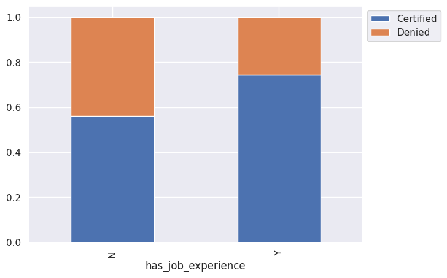

```python
stacked_barplot(data, "has_job_experience", "case_status")
```

- VISA applicants who have previous work experience show a higher certification rate (74%)
- VISA applicants without previous work experience have a certification rate of about 56%

#### **B6. Do the employees who have prior work experience require any job training?**

```python
count = data.loc[data['has_job_experience'] == 'Y'].groupby('requires_job_training')['requires_job_training'].count()

# Print results
print("Number of employees with job experience who require training: ", count['Y'])
print("Number of employees with job experience who do not require training: ", count['N'])
```

```
Number of employees with job experience who require training:  1265
Number of employees with job experience who do not require training:  13537
```

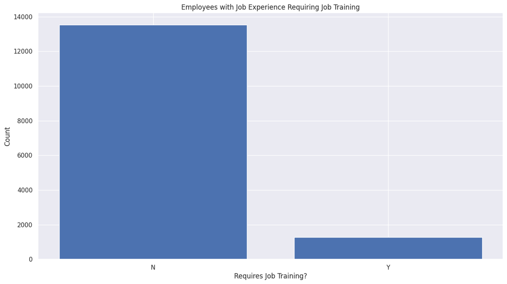

```python
# Create bar chart
plt.bar(count.index, count.values)
plt.title('Employees with Job Experience Requiring Job Training')
plt.xlabel('Requires Job Training?')
plt.ylabel('Count')
plt.show()
```

Visual shows that there is a higher count of visa applicants with work experience that do not require any additional training.

#### **B7. The US government has established a prevailing wage to protect local talent and foreign workers. Let's analyze the data and see if the visa status changes with the prevailing wage**

```python
data.groupby(["case_status"])["prevailing_wage"].describe()
```

| case_status | count | mean | std | min | 25% | 50% | 75% | max |
| --- | --- | --- | --- | --- | --- | --- | --- | --- |
| Certified | 17018.0000 | 77293.6192 | 52042.7156 | 2.1367 | 38375.3300 | 72486.2700 | 108879.1075 | 318446.0500 |
| Denied | 8462.0000 | 68748.6816 | 53890.1660 | 2.9561 | 23497.2950 | 65431.4600 | 105097.6400 | 319210.2700 |

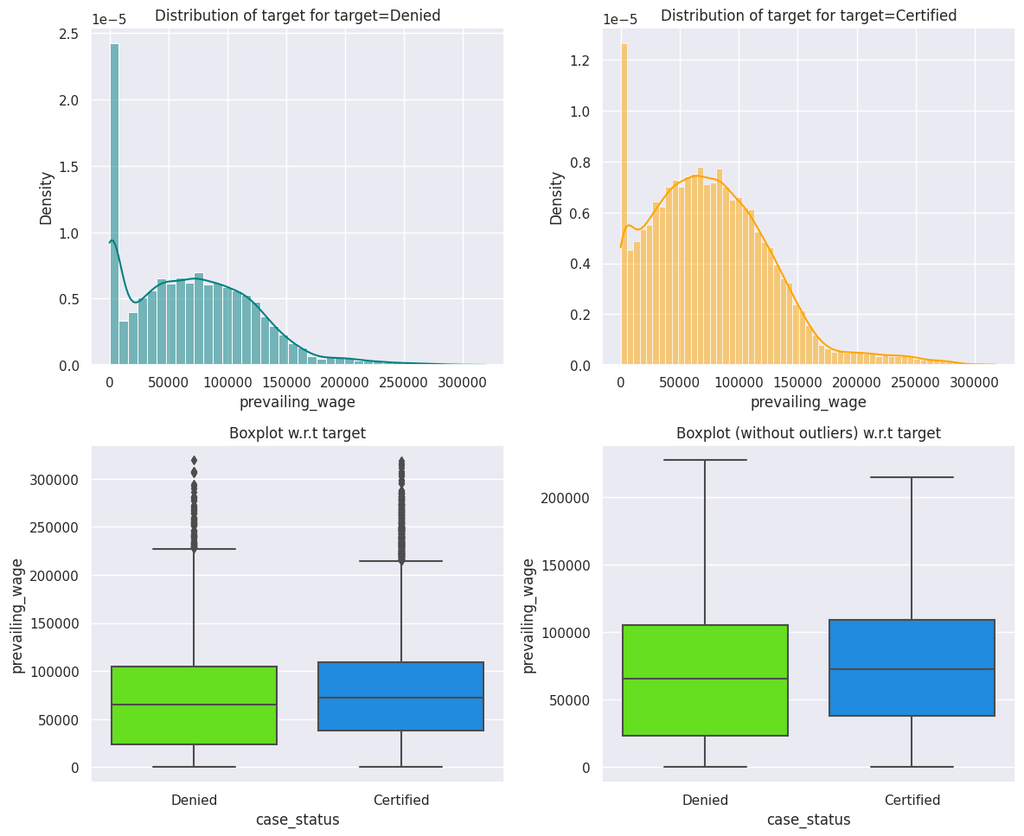

```python
distribution_plot_wrt_target(data, "prevailing_wage", "case_status")
```

**Observations**

**Using a two-sample t-test.**

- **Ho** = there is no difference in the mean prevailing wage between the two groups
- **Ha** = there is a significant difference

```python
'''
equal_var parameter is set to False to indicate
that we are assuming that the variances of the two groups are different.
ttest_ind() performs a two-sample t-test with unequal variances

syntax data.loc[row_labels, column_labels]
'''

import scipy.stats as stats

certified_wages = data.loc[data["case_status"] == "Certified", "prevailing_wage"]
denied_wages = data.loc[data["case_status"] == "Denied", "prevailing_wage"]

t_statistic, p_value = stats.ttest_ind(certified_wages, denied_wages, equal_var=False)

print("t-statistic:", t_statistic)
print("p-value:", p_value)
```

```
t-statistic: 12.05605927170979
p-value: 2.4940631935946944e-33
```

- Based on the t-statistic of 12.06 and a p-value that is less than a chosen significance level of 0.05, we can conclude that there is a significant difference between the mean prevailing wages of certified and denied visa applications.
- Therefore, we can reject the null hypothesis that the mean prevailing wages are equal and conclude that the prevailing wage does have an impact on the visa application status.

#### **B8. Checking if the prevailing wage is similar across all the regions of the US**

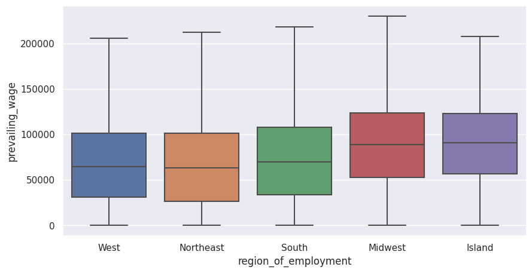

```python
plt.figure(figsize=(10, 5))
sns.boxplot(
    data=data,
    x="region_of_employment",
    y="prevailing_wage",
    showfliers=False,
)
plt.show()
```

**Observations**

- On average, West and Northeast regions have the lowest means previaling wage
- Midwest and Island regions have close average prevailing wage and also the highest prevailing_wages of the regions
- South region has higher previaling wage compared to West and Northeast region but lower than Midwest and Island regions

#### **B9. The prevailing wage has different units (Hourly, Weekly, etc). Let's find out if it has any impact on visa applications getting certified.**

```python
# create a crosstab table with percentage values
table = pd.crosstab(data['unit_of_wage'], data['case_status'], normalize='index')
table['All'] = table.sum(axis=1)

# display the table with percentage values using the to_string() method
# formatters parameter maps column names to formatting functions
print(table.to_string(formatters={'Certified': '{:.2%}'.format, 'Denied': '{:.2%}'.format, 'All': '{:.2%}'.format}))
```

```
case_status  Certified Denied     All
unit_of_wage
Hour            34.63% 65.37% 100.00%
Month           61.80% 38.20% 100.00%
Week            62.13% 37.87% 100.00%
Year            69.89% 30.11% 100.00%
```

```
case_status   Certified  Denied    All
unit_of_wage
All               17018    8462  25480
Year              16047    6915  22962
Hour                747    1410   2157
Week                169     103    272
Month                55      34     89
------------------------------------------------------------------------------------------------------------------------
```

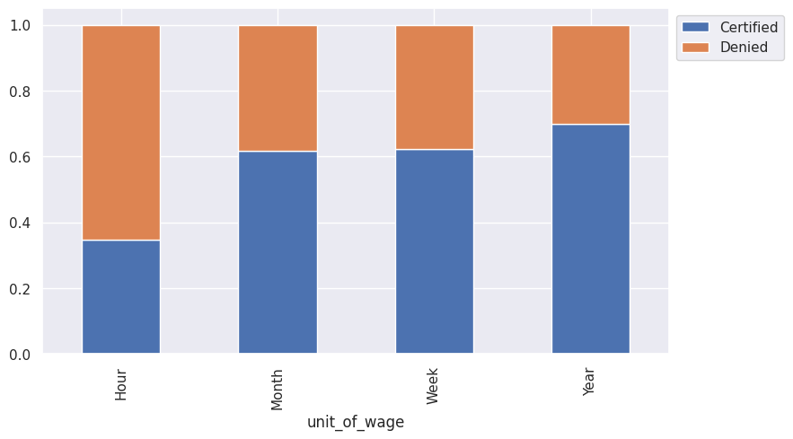

```python
stacked_barplot(data, "unit_of_wage", "case_status")
```

From the given data, it seems that the prevailing wage unit has an impact on visa applications getting certified.

- If we compare the certification rate of each wage unit, we can see that the yearly wage unit has the highest certification rate at 69.89% followed by monthly and weekly wage units at 61.80% and 62.13%, respectively.
- The hourly wage unit has the lowest certification rate at 34.63%.

It's important to note that the data suggests a correlation between the wage unit and certification rate, but it doesn't necessarily mean causation.

### **C. EDA - Multivariate Analysis**

#### **C1. Cluster analysis of visa status of applicants by their continent of origin, education level, and job experience.**

```python
# Subset the data to only include the variables of interest
subset_data = data[['continent', 'education_of_employee', 'has_job_experience', 'case_status']]

# Create a contingency table using the crosstab function
cont_table = pd.crosstab(index=[subset_data['continent'], subset_data['education_of_employee']],
                         columns=[subset_data['has_job_experience'], subset_data['case_status']])

# Print the contingency table
print(cont_table)
```

```
has_job_experience                          N                Y
case_status                         Certified Denied Certified Denied
continent     education_of_employee
Africa        Bachelor's                   32     32        49     30
              Doctorate                    14      8        29      3
              High School                   8     17        15     26
              Master's                     79     27       171     11
Asia          Bachelor's                 1495   1538      2912   1223
              Doctorate                   301    103       479     40
              High School                 276    652       400    962
              Master's                   1722    984      3427    347
Europe        Bachelor's                  418    120       622    139
              Doctorate                   325     33       463     25
              High School                  70    137        92    191
              Master's                    388     85       579     45
North America Bachelor's                  216    311       425    273
              Doctorate                    70     31       137     20
              High School                  57    108       153     83
              Master's                    298    257       681    172
Oceania       Bachelor's                   18     14        20     14
              Doctorate                    10      2         9      1
              High School                   5      9        14      8
              Master's                     18     13        28      9
South America Bachelor's                   52    102       108     71
              Doctorate                    34     10        41      4
              High School                  26     31        48     32
              Master's                     62     60       122     49
```

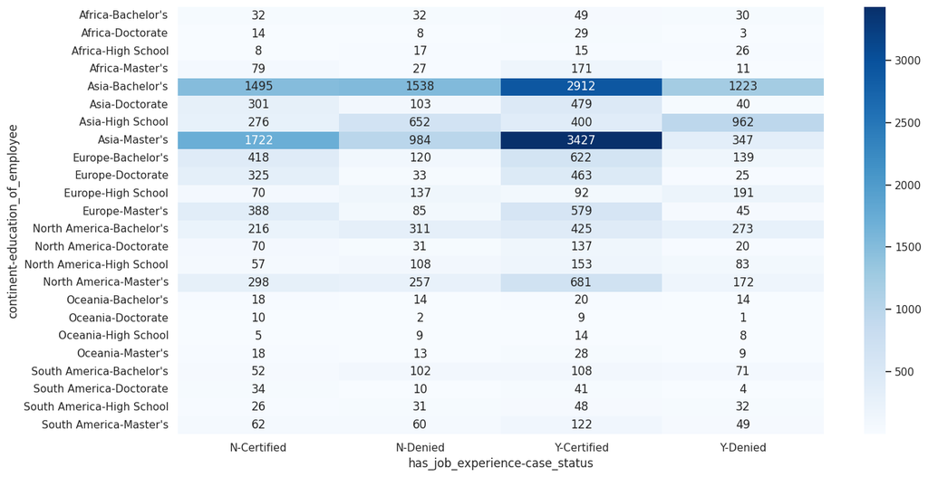

```python
# Create a heatmap of counts using the heatmap function from Seaborn
sns.heatmap(cont_table, cmap='Blues', annot=True, fmt='g')

# Show the plot
plt.show()
```

Overall, this analysis shows that factors like education level and job experience can have an impact on the certification rate of visa applicants, and that the certification rate can vary based on the applicant's continent of origin.

#### **C2.Linear Correlation between Numerical Variables**

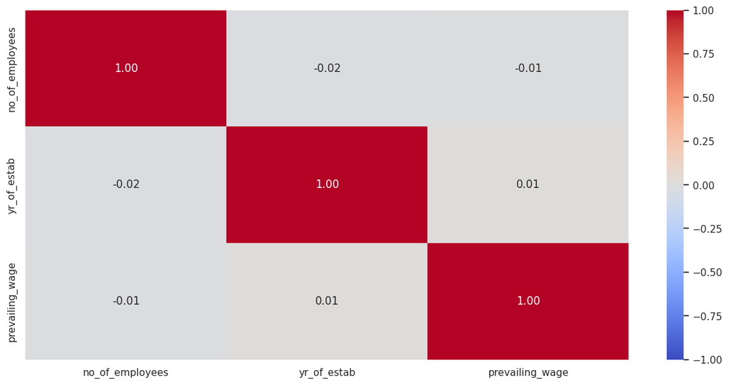

```python
# creating a list of numeric columns
numeric_columns = data.select_dtypes(include=np.number).columns.tolist()
# correlation heatmap
plt.figure(figsize=(15, 7))
sns.heatmap(
    data[numeric_columns].corr(),
    annot=True,
    vmin=-1,
    vmax=1,
    fmt=".2f",
    cmap="coolwarm",
);
```

**Observation**

- Negligible correlation obsered between numerical variables.

## Step 4. Data Preprocessing

- Missing value treatment (if needed)
- Dropping Unnecessary columns
- Categorical Encoding
- Feature engineering (if needed)
- Outlier detection and treatment (if needed)
- Preparing data for modeling
- Any other preprocessing steps (if needed)

### Converting the data types

```python
'''
One reason to fix the object dtype to category is to
reduce the memory usage of a DataFrame or a Series,
lead to faster processing times and the ability to
work with larger datasets that might not otherwise fit into memory.

Also beneficial for machine learning tasks

Note : Carrying this out under Step 4 rather than Step 3 : Sanity Check as corelation heatmap
was cleaner without the converted datatypes

cat-columns was declared under breakdown or verify the categorical data further
'''

for i in cat_columns:
    data[i] = data[i].astype("category")
```

```python
#lets check data type again after conversion and memory usage.
data.info()
```

```
<class 'pandas.core.frame.DataFrame'>
RangeIndex: 25480 entries, 0 to 25479
Data columns (total 11 columns):
 #   Column                 Non-Null Count  Dtype
---  ------                 --------------  -----
 0   continent              25480 non-null  category
 1   education_of_employee  25480 non-null  category
 2   has_job_experience     25480 non-null  category
 3   requires_job_training  25480 non-null  category
 4   no_of_employees        25480 non-null  int64
 5   yr_of_estab            25480 non-null  int64
 6   region_of_employment   25480 non-null  category
 7   prevailing_wage        25480 non-null  float64
 8   unit_of_wage           25480 non-null  category
 9   full_time_position     25480 non-null  category
 10  case_status            25480 non-null  category
dtypes: category(8), float64(1), int64(2)
memory usage: 797.7 KB
```

**Observation**

- All object dtypes converted to category.
- Memeory usage reduced from 2.3+ MB to 798Kb with case_Id column dropped.

### Encoding Categorical Data

1. Machine learning algorithms typically work with numerical data, and cannot process categorical data directly. Therefore, we need to encode categorical data into numerical values to enable machine learning algorithms to work with them.
2. Algorithms, such as decision trees and random forests, can handle categorical variables directly. Hence we will only encode some of the columns as below.
   - We will encode the following categrical variable columns except case_status which will be done under Data Split : has_job_experience, requires_job_training, full_time_position and education_of_employee (because it has a natural order or hierarchy)

```python
# transform has_job_experience, requires_job_training and full_time_position
# Replace 'Y' with 1 and 'N' with 0

# Select the columns to encode and replace 'Y' with 1 and 'N' with 0
data[['has_job_experience', 'requires_job_training', 'full_time_position']] = data[['has_job_experience', 'requires_job_training', 'full_time_position']].replace({'Y': 1, 'N': 0})
```

```python
# transform education_of_employee by hierarchy
# Use a lambda function to replace the education categories with numerical values
data['education_of_employee'] = data['education_of_employee'].apply(
    lambda x: 1 if x == 'High School' else (2 if x == "Bachelor's" else (3 if x == "Master's" else 4)))
```

```python
#lets check the updates are all binary or numerical
updated_col = ['has_job_experience', 'requires_job_training', 'full_time_position','education_of_employee']

for i in updated_col:
    print(data[i].value_counts())
    print("*" * 40)
    print("\n")
```

```
1    14802
0    10678
Name: has_job_experience, dtype: int64


0    22525
1     2955
Name: requires_job_training, dtype: int64


1    22773
0     2707
Name: full_time_position, dtype: int64


2    10234
3     9634
1     3420
4     2192
Name: education_of_employee, dtype: int64
```

### Feature Engineering

Create new features from the available data that is relevant to the machine learning objective. We shall carry out feature egineering on the year of establishment column in the dataset

```python
# Add a new column, total_yr_estab, and drop the original column therafter
# from the univariate analysis, we knw that the max year is 2016.

data["total_yr_estab"] = 2016 - data.yr_of_estab

# Drop yr_of_estab
data.drop("yr_of_estab", axis=1, inplace=True)
```

```python
# Check the updated columns, dropped yr_of_estab and new column total_yr_estab is present
print(data.columns)
print('\n')

# Preview the first few rows of the updated dataframe
print(data.head())
```

```
Index(['continent', 'education_of_employee', 'has_job_experience',
       'requires_job_training', 'no_of_employees', 'region_of_employment',
       'prevailing_wage', 'unit_of_wage', 'full_time_position', 'case_status',
       'total_yr_estab'],
      dtype='object')


  continent education_of_employee has_job_experience requires_job_training  \
0      Asia                     1                  0                     0
1      Asia                     3                  1                     0
2      Asia                     2                  0                     1
3      Asia                     2                  0                     0
4    Africa                     3                  1                     0

   no_of_employees region_of_employment  prevailing_wage unit_of_wage  \
0            14513                 West         592.2029         Hour
1             2412            Northeast       83425.6500         Year
2            44444                 West      122996.8600         Year
3               98                 West       83434.0300         Year
4             1082                South      149907.3900         Year

  full_time_position case_status  total_yr_estab
0                  1      Denied               9
1                  1   Certified              14
2                  1      Denied               8
3                  1      Denied             119
4                  1   Certified              11
```

### **Outliers detection**

- Let's check for outliers in the data.

```python
numeric_columns = data.select_dtypes(include=np.number).columns.tolist()

# Print the list of numerical columns
print(numeric_columns)
print('No of numerical columns are :',len(numeric_columns))
```

```
['no_of_employees', 'prevailing_wage', 'total_yr_estab']
No of numerical columns are : 3
```

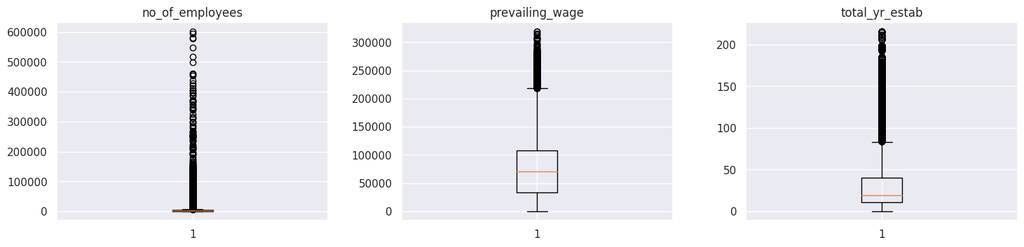

```python
#Let's check for outliers in the data using boxplots
# to prevent errors in defiing the number of subplots, we can use the ceiling mathematical function to determine the best number of subplots to plot

import math
n_rows = int(math.ceil(len(numeric_columns)/4))
plt.figure(figsize=(20, n_rows*4))

for i, variable in enumerate(numeric_columns):
    plt.subplot(n_rows, 4, i + 1)         # n_rows by 4 cols
    plt.boxplot(data[variable], whis=1.5)
    plt.tight_layout(pad = 2)
    plt.title(variable)

plt.show()
```

- There are quite a few outliers in the numerical data.
- However, we will not treat them as they could be proper values, including total year established for companies which is over 200 years.

### Data Preparation for modeling

- We want to predict which visa will be certified.
- Before we proceed to build a model, we'll have to encode categorical features.
- We'll split the data into train and test to be able to evaluate the model that we build on the train data.

*Student Note :*

Steps for comparing the performance metrics between various models:

1. Split the dataset into training and testing sets.
2. Choose different models to build and train them on the training set.
3. Evaluate the performance of each model on the testing set using appropriate performance metrics such as accuracy, precision, recall, F1-score, AUC-ROC, etc.
4. Compare the performance metrics of each model to determine the best performing model.
5. Perform cross-validation to validate the model's performance.
6. Fine-tune the hyperparameters of the best performing model using grid search or random search.
7. Re-evaluate the performance of the tuned model and compare it to the performance of the other models.
8. Choose the best model based on the performance metrics for deployment/use

### Split the dataset

```python
### Transform case_status to 1 for Certified and 0 Denied
data["case_status"] = data["case_status"].apply(lambda x: 1 if x == "Certified" else 0)
```

```python
#Separating features and the target column
X = data.drop(
    ["case_status"], axis=1)
Y = data["case_status"]
```

```python
# creating dummy variables
X = pd.get_dummies(X, drop_first=True)
```

```python
# Splitting data in train and test sets in the ratio 70:30
X_train, X_test, y_train, y_test = train_test_split(
    X, Y, test_size=0.3, random_state=1, stratify=Y)
```

```python
print("Shape of Training set : ", X_train.shape)
print("Shape of test set : ", X_test.shape)
print("Percentage of classes in training set:")
print(y_train.value_counts(normalize=True))
print("Percentage of classes in test set:")
print(y_test.value_counts(normalize=True))
```

```
Shape of Training set :  (17836, 21)
Shape of test set :  (7644, 21)
Percentage of classes in training set:
1   0.6679
0   0.3321
Name: case_status, dtype: float64
Percentage of classes in test set:
1   0.6678
0   0.3322
Name: case_status, dtype: float64
```

From the given information, we can infer the following:

- The training set has 17,836 observations and 21 columns/ features.
- The test set has 7,644 observations and 21 columns/features.
- In the training set, 66.79% of the observations are labeled as 1 and 33.21% are labeled as 0.
- In the test set, 66.78% of the observations are labeled as 1 and 33.22% are labeled as 0.
- This information suggests that both the training and test sets have a similar distribution of classes in the target variable, with a slight class imbalance towards the positive class (labeled as 1).
- The proportion of positive and negative classes in both the training and test sets is relatively balanced, with the positive class accounting for roughly two-thirds of the data and the negative class accounting for roughly one-third of the data.

*Note : Stratify has maintained the distribution of classes when splitting to a train and test dataset*

### Model evaluation criterion

### Model can make wrong predictions as:

1. Model predicts that the visa application will get certified but in reality, the visa application should get denied.
2. Model predicts that the visa application will not get certified but in reality, the visa application should get certified.

### Which case is more important?

- Both the cases are important as:
- If a visa is certified when it had to be denied a wrong employee will get the job position while US citizens will miss the opportunity to work on that position.
- If a visa is denied when it had to be certified the U.S. will lose a suitable human resource that can contribute to the economy.

### How to reduce the losses?

- `F1 Score` can be used a the metric for evaluation of the model, greater the F1 score higher are the chances of minimizing False Negatives and False Positives.
- We will use balanced class weights so that model focuses equally on both classes.

#### **First, let's create functions to calculate different metrics and confusion matrix so that we don't have to use the same code repeatedly for each model**.

- The model_performance_classification_sklearn function will be used to check the model performance of models.
- The confusion_matrix_sklearn function will be used to plot the confusion matrix.

```python
# defining a function to compute different metrics to check performance of a classification model built using sklearn


def model_performance_classification_sklearn(model, predictors, target):
    """
    Function to compute different metrics to check classification model performance

    model: classifier
    predictors: independent variables
    target: dependent variable
    """

    # predicting using the independent variables
    pred = model.predict(predictors)

    acc = accuracy_score(target, pred)  # to compute Accuracy
    recall = recall_score(target, pred)  # to compute Recall
    precision = precision_score(target, pred)  # to compute Precision
    f1 = f1_score(target, pred)  # to compute F1-score

    # creating a dataframe of metrics
    df_perf = pd.DataFrame(
        {"Accuracy": acc, "Recall": recall, "Precision": precision, "F1": f1,},
        index=[0],
    )

    return df_perf
```

```python
def confusion_matrix_sklearn(model, predictors, target):
    """
    To plot the confusion_matrix with percentages

    model: classifier
    predictors: independent variables
    target: dependent variable
    """
    y_pred = model.predict(predictors)
    cm = confusion_matrix(target, y_pred)
    labels = np.asarray(
        [
            ["{0:0.0f}".format(item) + "\n{0:.2%}".format(item / cm.flatten().sum())]
            for item in cm.flatten()
        ]
    ).reshape(2, 2)

    plt.figure(figsize=(6, 4))
    sns.heatmap(cm, annot=labels, fmt="")
    plt.ylabel("True label")
    plt.xlabel("Predicted label")
```

## Decision Tree - Model Building and Hyperparameter Tuning

### Decision Tree Model

```python
#code to define decision tree classifier with random state = 1
model = DecisionTreeClassifier(
    criterion="gini", class_weight={0: 0.668, 1: 0.332}, random_state=1)

#code to fit decision tree classifier on the train data
model.fit(X_train, y_train)
```

```
DecisionTreeClassifier(class_weight={0: 0.668, 1: 0.332}, random_state=1)
```

#### Checking model performance on training set

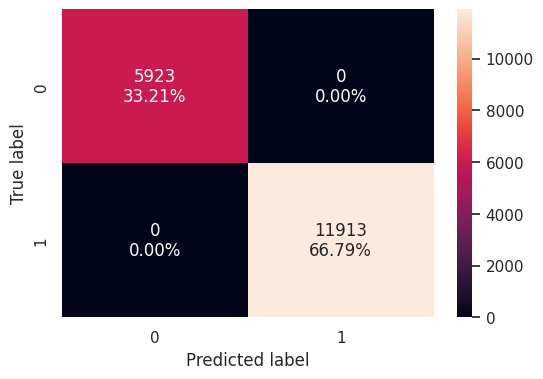

```python
confusion_matrix_sklearn(model, X_train, y_train)  ## create confusion matrix for train data
```

```python
#code to check performance on train data

decision_tree_perf_train = model_performance_classification_sklearn(
    model, X_train, y_train)
decision_tree_perf_train
```

|  | Accuracy | Recall | Precision | F1 |
| --- | --- | --- | --- | --- |
| 0 | 1.0000 | 1.0000 | 1.0000 | 1.0000 |

#### Checking model performance on test set

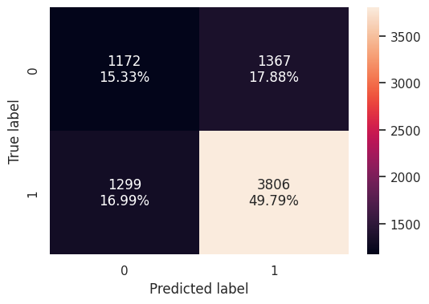

```python
## code to create confusion matrix for test data
confusion_matrix_sklearn(model, X_test, y_test)
```

```python
## code to check performance for test data
decision_tree_perf_test = model_performance_classification_sklearn(
    model, X_test, y_test)
decision_tree_perf_test
```

|  | Accuracy | Recall | Precision | F1 |
| --- | --- | --- | --- | --- |
| 0 | 0.6512 | 0.7455 | 0.7357 | 0.7406 |

- The provided information shows the performance of a decision tree classifier that was trained with imbalanced classes, where the negative class (0) represents 33.21% of the training data and the positive class (1) represents 66.79% of the training data.
- From the training performance, we can see that
  - the model is able to achieve a perfect accuracy of 1.0 for accuracy, recall, precision, and F1-score. This is likely due to reasons that the training data is highly imbalanced, with the positive class being over twice as large as the negative class and
  - the classifier is able to predict all the training examples correctly.
  - This could be an indication of overfitting, where the model has memorized the training data and may not generalize well to new data.
- On the test set, the accuracy was 0.6512, indicating that the classifier correctly predicted the class of only 65.12% of the test instances. The recall was 0.7455, indicating that the classifier correctly identified 74.55% of the positive instances in the test set. The precision was 0.7357, indicating that of all the instances predicted as positive by the classifier, only 73.57% were actually positive. The F1-score was 0.7406, which is the harmonic mean of the precision and recall.
  - the testing performance of the model is not as good as the training performance, which is expected. This also indicates an overfitting since the performance metric is significantly better on the training dataset than on the testing dataset.
  - We can improve model performance by hyperparameter tuning

*Confusion Matrix Inference*

- TN (True Negatives): Applicant visa was denied and the model predicted denial. (0-0)
- FP (False Positives): Applicant visa was denied and the model predicted approval. (0-1)
- FN (False Negatives): Applicant visa was approved and the model predicted denied. (1-0)
- TP (True Positives): Applicant visa was approved and the model predicted approval. (1-1)

*In summary, while the decision tree classifier achieved perfect performance on the imbalanced training data, it did not generalize well to the test data, suggesting that the classifier may be overfitting to the training data.*